# SF Bay Microplastics Probability Distributions

Scott Coffin

1/13/2021

The objective of this project is to determine site-specific SSDs for plastic particles in the SF Bay. Particle distribution data for plastic particles is from Dr. Diana Lin at SFEI.

#library

```r
library(tidyverse)
library(ssdtools)
library(fitdistrplus)
library(rbin)
```

# 1 SF Bay Data

## 1.1 Import data

```r
#site-specific distribution data
#SF bay data
distributions <- readxl::read_xlsx("data/2020-09-08_MooreParticleData.xlsx") %>%
  mutate(Size_um = Length.mm) %>%
  mutate(matrix = case_when(grepl("sediment", MatrixName) ~ "sediment",
                            grepl("runoff", MatrixName) ~ "runoff",
                            grepl("samplewater", MatrixName) ~ "samplewater",
                            grepl("tissue", MatrixName) ~ "tissue",
                            grepl("blankwater", MatrixName) ~ "blankwater",
                            grepl("effluent", MatrixName) ~ "effluent")) %>%
  mutate(lower_size_limit_um = as.numeric(case_when(grepl(">125",MatrixName) ~ "125",
                                                 grepl(">355",MatrixName) ~ "355",
                                                 grepl(">500",MatrixName) ~ "500",
                                                 grepl(">1",MatrixName) ~ "1000"))) %>%
  mutate(upper_size_limit_um = as.numeric(case_when(grepl("125 um",MatrixName) ~ "125",
                                                 grepl("355 um",MatrixName) ~ "355",
                                                 grepl("500 um",MatrixName) ~ "500",
                                                 grepl("1000 um",MatrixName) ~ "1000"))) %>%
  mutate_if(is.character,  as.factor)

skimr::skim(distributions)
```

Data summary

| Name | distributions |
| --- | --- |
| Number of rows | 44226 |
| Number of columns | 12 |
| _______________________ |  |
| Column type frequency: |  |
| factor | 7 |
| numeric | 5 |
| ________________________ |  |
| Group variables | None |

**Variable type: factor**

| skim_variable | n_missing | complete_rate | ordered | n_unique | top_counts |
| --- | --- | --- | --- | --- | --- |
| SampleMatrix | 0 | 1 | FALSE | 5 | man: 20164, sw: 12525, sed: 6022, eff: 3510 |
| SampleID | 0 | 1 | FALSE | 306 | CB9: 4957, CB8: 2675, 19-: 2346, SB1: 1848 |
| PlasticType | 0 | 1 | FALSE | 49 | Not: 37107, Ant: 1545, Pol: 1174, Pol: 507 |
| MorphologicalCategory | 5 | 1 | FALSE | 6 | Fib: 22012, Fra: 17804, Foa: 2507, Fil: 975 |
| Color | 20 | 1 | FALSE | 18 | Bla: 11751, Cle: 8945, Whi: 5991, Blu: 5947 |
| MatrixName | 0 | 1 | FALSE | 19 | sam: 15841, run: 8360, sed: 3936, tis: 2005 |
| matrix | 0 | 1 | FALSE | 6 | sam: 20164, run: 12401, sed: 6022, eff: 3424 |

**Variable type: numeric**

| skim_variable | n_missing | complete_rate | mean | sd | p0 | p25 | p50 | p75 | p100 | hist |
| --- | --- | --- | --- | --- | --- | --- | --- | --- | --- | --- |
| Length.mm | 24069 | 0.46 | 2.05 | 21.89 | 0 | 0.49 | 0.98 | 1.99 | 3034 | ▇▁▁▁▁ |
| Width.mm | 24045 | 0.46 | 0.40 | 2.71 | 0 | 0.02 | 0.04 | 0.32 | 270 | ▇▁▁▁▁ |
| Size_um | 24069 | 0.46 | 2.05 | 21.89 | 0 | 0.49 | 0.98 | 1.99 | 3034 | ▇▁▁▁▁ |
| lower_size_limit_um | 2231 | 0.95 | 240.35 | 221.84 | 125 | 125.00 | 125.00 | 355.00 | 1000 | ▇▂▁▁▁ |
| upper_size_limit_um | 3717 | 0.92 | 440.71 | 199.26 | 355 | 355.00 | 355.00 | 355.00 | 1000 | ▇▁▁▁▁ |

## 1.2 Modelling

### 1.2.1 Visualization

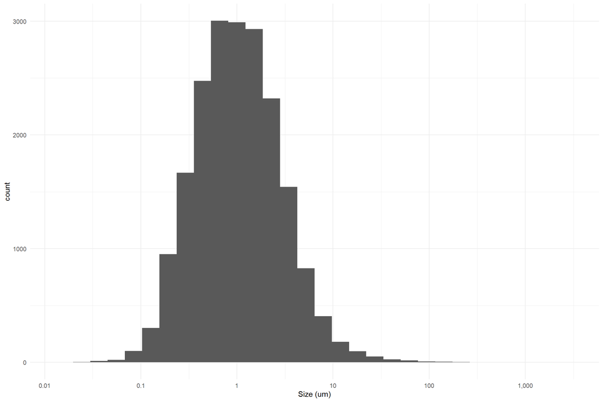

```r
distributions %>%
  ggplot(aes(x = Size_um)) +
  geom_histogram() +
  scale_x_continuous(name = "Size (um)",breaks = scales::trans_breaks("log10", function(x) 10^x),labels = comma_signif, trans = "log10")+
  theme_minimal()
```

We can see here that they do not exactly follow an alpha distribution, but this is likely due to detection limits.

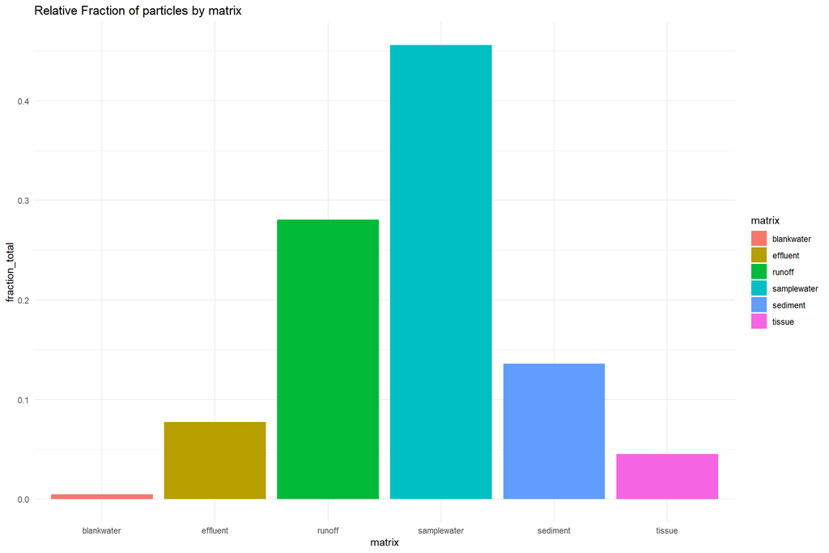

```r
distributions %>%
  group_by(matrix) %>%
  summarize(count = n()) %>%
  mutate(fraction_total = count /  sum(count)) %>%
  ggplot(aes(x = matrix, y = fraction_total, fill = matrix)) +
  geom_col() +
  labs(title = "Relative Fraction of particles by matrix") +
  theme_minimal()
```

#### 1.2.1.1 Average Density

1. Data was plotted using only the values between the minimum and the first non-detect. A log-log plot for size vs abundance (#) is made.
2. A linear trendline was fitted, and the parameters for the function y = a*x + b were obtained
3. Assuming y = 0 (equals 1 particle since 10^0 = 1), a value for x (the PDL) was calculated
4. Data were plotted using only the values between the minimum and the calculated PDL
5. If more data were included than in step 1, the procedure was repeated.
6. Once the PDL does not change anymore, only data between the minimum and PDL were included for the final trendline fitting.

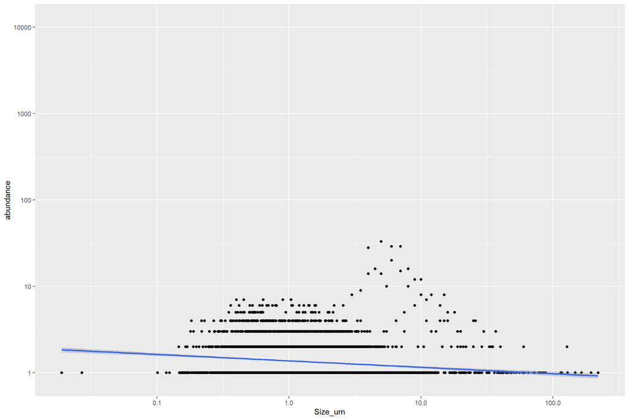

```r
sample_water <- distributions %>%
  filter(matrix == "samplewater") %>%
  group_by(Size_um, lower_size_limit_um, upper_size_limit_um) %>%
  summarize(abundance = n())

sample_water %>%
  ggplot(aes(x = Size_um, y = abundance)) +
  geom_point() +
  geom_smooth(method = "lm") +
  scale_x_log10() +
  scale_y_log10()
```

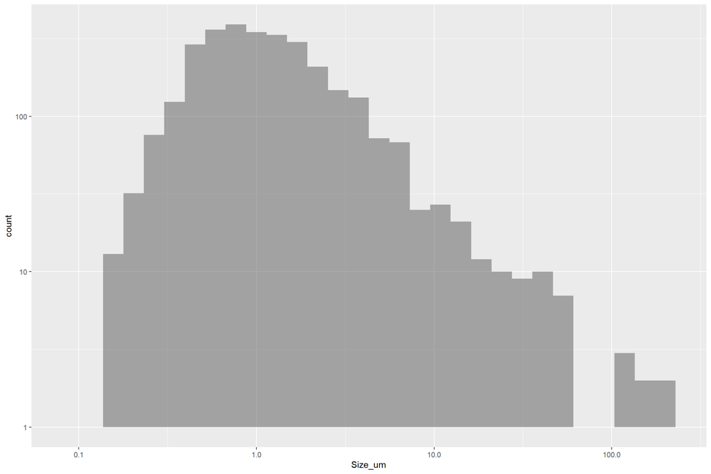

```r
distributions %>%
  filter(matrix == "samplewater") %>%
  filter(MorphologicalCategory == "Fragment") %>%
  ggplot(aes(x = Size_um)) +
  geom_histogram(alpha = 0.5) +
 # geom_smooth(method = "lm") +
  scale_x_log10() +
  scale_y_log10()
```

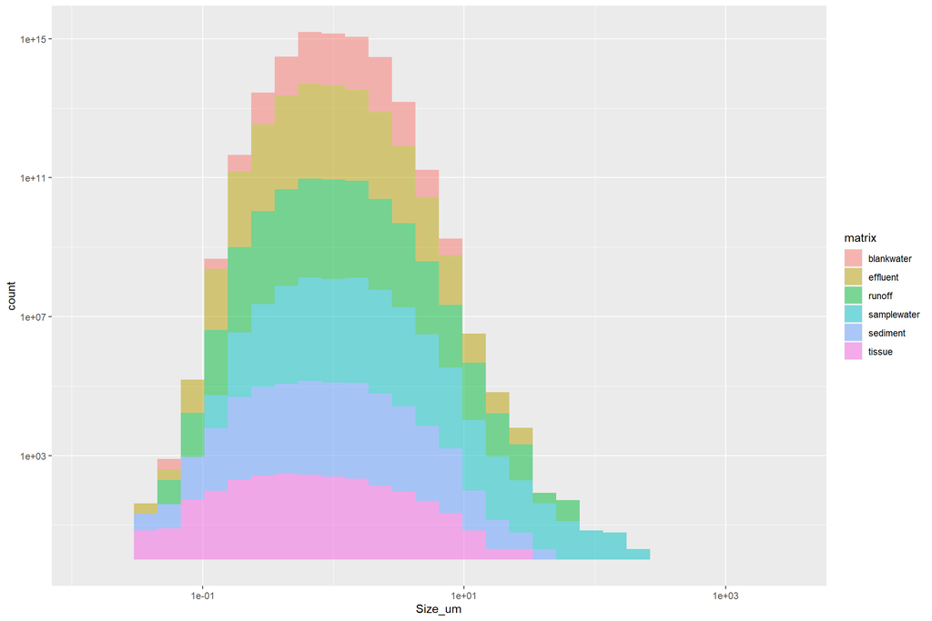

```r
distributions %>%
  #filter(matrix == "samplewater") %>%
  #filter(MorphologicalCategory == "Fragment") %>%
  ggplot(aes(x = Size_um, fill = matrix)) +
  geom_histogram(alpha = 0.5) +
 # geom_smooth(method = "lm") +
  scale_x_log10() +
  scale_y_log10()
```

We need a better way of binning data.

Winsorized binning is similar to equal length binning except that both tails are cut off to obtain a smooth binning result. This technique is often used to remove outliers during the data pre-processing stage. For Winsorized binning, the Winsorized statistics are computed first. After the minimum and maximum have been found, the split points are calculated the same way as in equal length binning.

#### 1.2.2.1 SampleWater

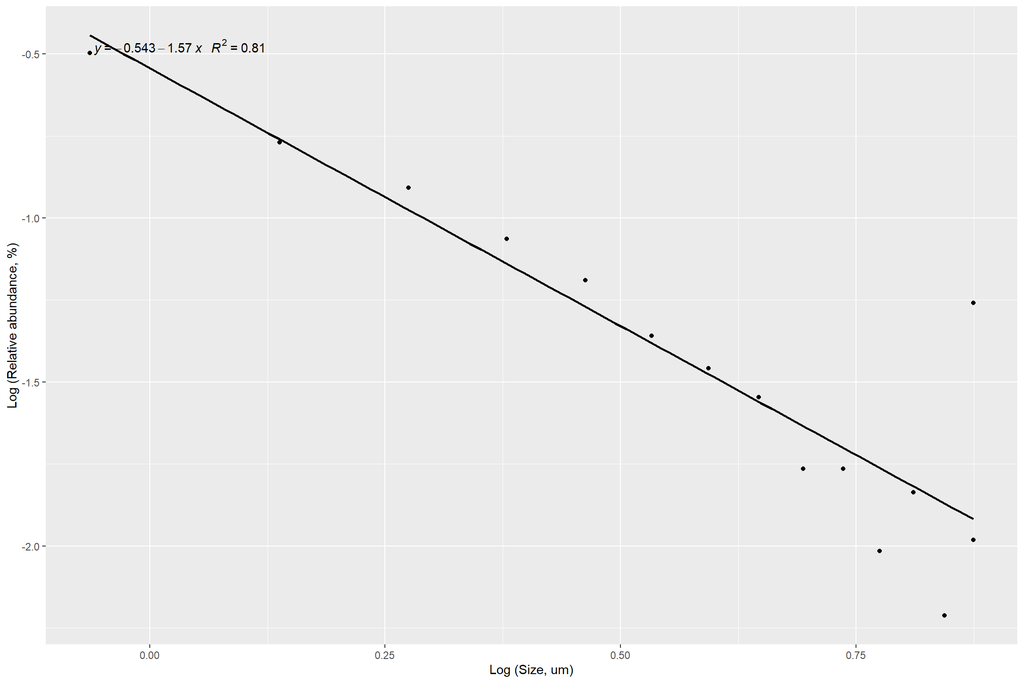

```r
#determine lower and upper end based on maximum R^2 (iteration required)
sample_water_cut <- distributions %>%
  #filter(lower_size_limit_um == 125) %>%
 # filter(MorphologicalCategory == "Fragment") %>%
  filter(matrix == "samplewater") %>%
  #filter(Size_um >1 & Size_um  <1000) %>%
  drop_na(Size_um)

#cut into bins
#sample_waterwinsors <- rbin_winsorize(sample_water_cut, polymer, Size_um, 20)
sample_waterwinsors <- rbin_winsorize(sample_water_cut, predictor = Length.mm, Length.mm, 15, winsor_rate = 0.05)
#save as dataframe
sample_waterbinned <- as.data.frame(sample_waterwinsors$bins) %>%
  dplyr::select(c(cut_point, bin_count, bin_prop))

#strip of characters
sample_waterbinned$cut <- gsub("[^0-9.-]","",sample_waterbinned$cut_point)
 #convert to numeric
sample_waterbinned2 <- sample_waterbinned %>%
  mutate(cut.numeric = as.numeric(cut)) %>%
  mutate(logAbundance = log10(bin_prop),
         logSize = log10(cut.numeric))

## model
library(ggpmisc)
my.formula <- y ~ x
p <- sample_waterbinned2 %>%
  #filter(logAbundance < -1.0) %>%
  ggplot(aes(x = logSize, y = logAbundance)) +
   geom_smooth(method = "lm", se=FALSE, color="black", formula = my.formula) +
   stat_poly_eq(formula = my.formula,
                aes(label = paste(..eq.label.., ..rr.label.., sep = "~~~")),
                parse = TRUE) +
   geom_point() +
  xlab("Log (Size, um)") +
  ylab("Log (Relative abundance, %)")
p
```

##### 1.2.2.1.1 Remove outliers

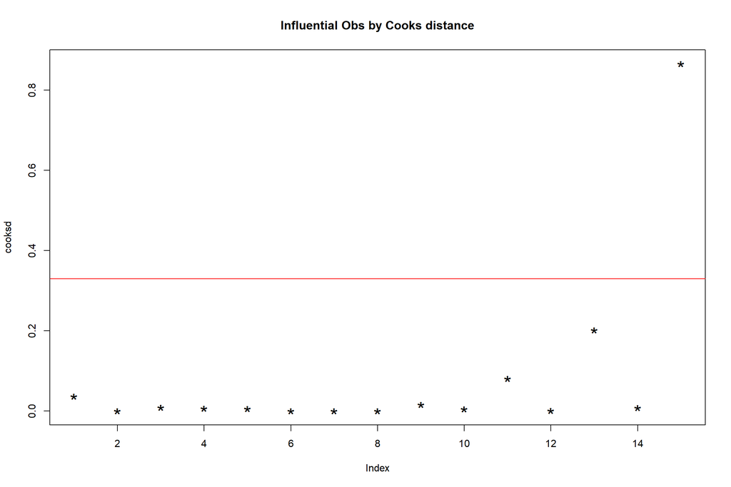

```r
sample_waterlin <- lm(logAbundance ~ logSize, data = sample_waterbinned2)
cooksd <- cooks.distance(sample_waterlin)
plot(cooksd, pch="*", cex=2, main="Influential Obs by Cooks distance")  # plot cook's distance
abline(h = 4*mean(cooksd, na.rm=T), col="red")  # add cutoff line
text(x=1:length(cooksd)+1, y=cooksd, labels=ifelse(cooksd>4*mean(cooksd, na.rm=T),names(cooksd),""), col="red")  # add labels
```

Extract outliers

```r
influential <- as.numeric(names(cooksd)[(cooksd > 4*mean(cooksd, na.rm=T))])  # influential row numbers
head(sample_waterbinned2[influential, ])  # influential observations.
```

```
##              cut_point bin_count   bin_prop              cut cut.numeric
## 15 >= 7.49026666666667       359 0.05507824 7.49026666666667    7.490267
##    logAbundance   logSize
## 15     -1.25902 0.8744973
```

```r
trimmedsample_water <- sample_waterbinned2 %>%
  filter(cut_point != c(">= 7.49026666666667")
) %>%
  mutate(polymer = "sample_water")

sample_waterlin <- lm(logAbundance ~ logSize, data = trimmedsample_water)
sample_waterlin.summ <- summary(sample_waterlin)
sample_waterlin.summ
```

```
##
## Call:
## lm(formula = logAbundance ~ logSize, data = trimmedsample_water)
##
## Residuals:
##      Min       1Q   Median       3Q      Max
## -0.23461 -0.05242  0.05440  0.07833  0.11004
##
## Coefficients:
##             Estimate Std. Error t value Pr(>|t|)
## (Intercept) -0.47702    0.06791  -7.025 1.39e-05 ***
## logSize     -1.77799    0.11068 -16.065 1.77e-09 ***
## ---
## Signif. codes:  0 '***' 0.001 '**' 0.01 '*' 0.05 '.' 0.1 ' ' 1
##
## Residual standard error: 0.1127 on 12 degrees of freedom
## Multiple R-squared:  0.9556, Adjusted R-squared:  0.9519
## F-statistic: 258.1 on 1 and 12 DF,  p-value: 1.77e-09
```

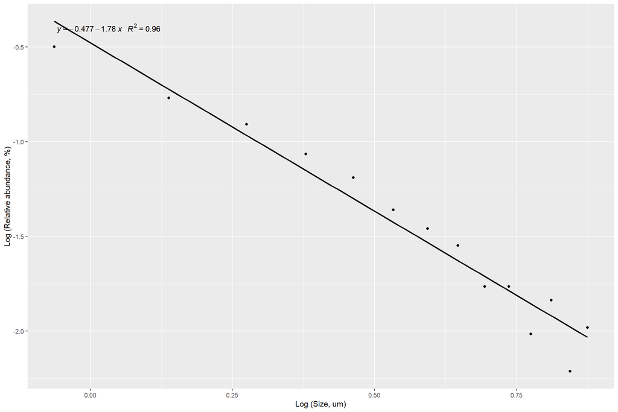

```r
ggplot(data = trimmedsample_water, aes(x = logSize, y = logAbundance)) +
   geom_smooth(method = "lm", se=FALSE, color="black", formula = my.formula) +
   stat_poly_eq(formula = my.formula,
                aes(label = paste(..eq.label.., ..rr.label.., sep = "~~~")),
                parse = TRUE) +
   geom_point() +
  xlab("Log (Size, um)") +
  ylab("Log (Relative abundance, %)")
```

### 1.2.3 Effluent

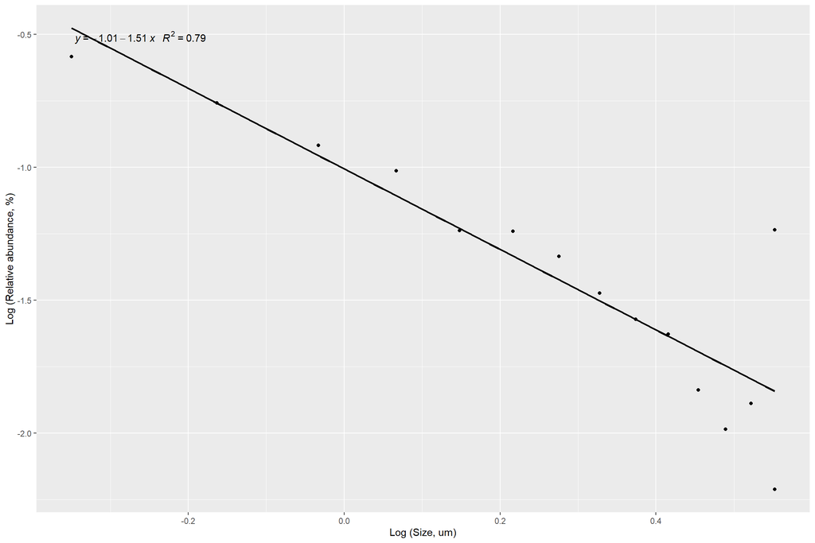

```r
#determine lower and upper end based on maximum R^2 (iteration required)
effluent_cut <- distributions %>%
  #filter(lower_size_limit_um == 125) %>%
 # filter(MorphologicalCategory == "Fragment") %>%
  filter(matrix == "effluent") %>%
  #filter(Size_um >1 & Size_um  <1000) %>%
  drop_na(Size_um)

#cut into bins
#effluentwinsors <- rbin_winsorize(effluent_cut, polymer, Size_um, 20)
effluentwinsors <- rbin_winsorize(effluent_cut, predictor = Length.mm, Length.mm, 15, winsor_rate = 0.05)
#save as dataframe
effluentbinned <- as.data.frame(effluentwinsors$bins) %>%
  dplyr::select(c(cut_point, bin_count, bin_prop))

#strip of characters
effluentbinned$cut <- gsub("[^0-9.-]","",effluentbinned$cut_point)
 #convert to numeric
effluentbinned2 <- effluentbinned %>%
  mutate(cut.numeric = as.numeric(cut)) %>%
  mutate(logAbundance = log10(bin_prop),
         logSize = log10(cut.numeric))

## model
library(ggpmisc)
my.formula <- y ~ x
p <- effluentbinned2 %>%
  #filter(logAbundance < -1.0) %>%
  ggplot(aes(x = logSize, y = logAbundance)) +
   geom_smooth(method = "lm", se=FALSE, color="black", formula = my.formula) +
   stat_poly_eq(formula = my.formula,
                aes(label = paste(..eq.label.., ..rr.label.., sep = "~~~")),
                parse = TRUE) +
   geom_point() +
  xlab("Log (Size, um)") +
  ylab("Log (Relative abundance, %)")
p
```

##### 1.2.3.0.1 Remove outliers

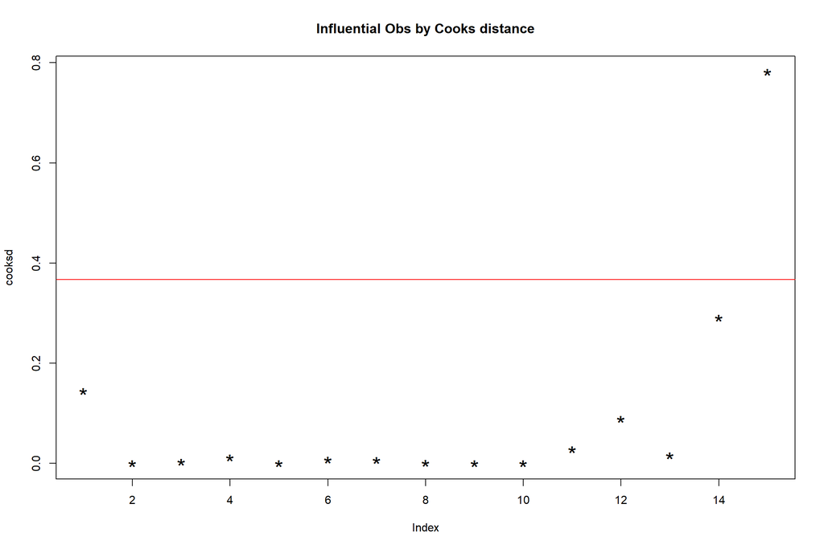

```r
effluentlin <- lm(logAbundance ~ logSize, data = effluentbinned2)
cooksd <- cooks.distance(effluentlin)
plot(cooksd, pch="*", cex=2, main="Influential Obs by Cooks distance")  # plot cook's distance
abline(h = 4*mean(cooksd, na.rm=T), col="red")  # add cutoff line
text(x=1:length(cooksd)+1, y=cooksd, labels=ifelse(cooksd>4*mean(cooksd, na.rm=T),names(cooksd),""), col="red")  # add labels
```

Extract outliers

```r
influential <- as.numeric(names(cooksd)[(cooksd > 4*mean(cooksd, na.rm=T))])  # influential row numbers
head(effluentbinned2[influential, ])  # influential observations.
```

```
##              cut_point bin_count bin_prop              cut cut.numeric
## 15 >= 3.56564666666666       180 0.058102 3.56564666666666    3.565647
##    logAbundance   logSize
## 15    -1.235809 0.5521383
```

```r
trimmedeffluent <- effluentbinned2 %>%
  filter(cut_point != c(">= 3.56564666666666")
) %>%
  mutate(polymer = "effluent")

effluentlin <- lm(logAbundance ~ logSize, data = trimmedeffluent)
effluentlin.summ <- summary(effluentlin)
effluentlin.summ
```

```
##
## Call:
## lm(formula = logAbundance ~ logSize, data = trimmedeffluent)
##
## Residuals:
##      Min       1Q   Median       3Q      Max
## -0.26342 -0.05122  0.02319  0.08955  0.13933
##
## Coefficients:
##             Estimate Std. Error t value Pr(>|t|)
## (Intercept) -1.00280    0.04603  -21.79 5.13e-11 ***
## logSize     -1.71353    0.13047  -13.13 1.76e-08 ***
## ---
## Signif. codes:  0 '***' 0.001 '**' 0.01 '*' 0.05 '.' 0.1 ' ' 1
##
## Residual standard error: 0.1283 on 12 degrees of freedom
## Multiple R-squared:  0.935,  Adjusted R-squared:  0.9295
## F-statistic: 172.5 on 1 and 12 DF,  p-value: 1.759e-08
```

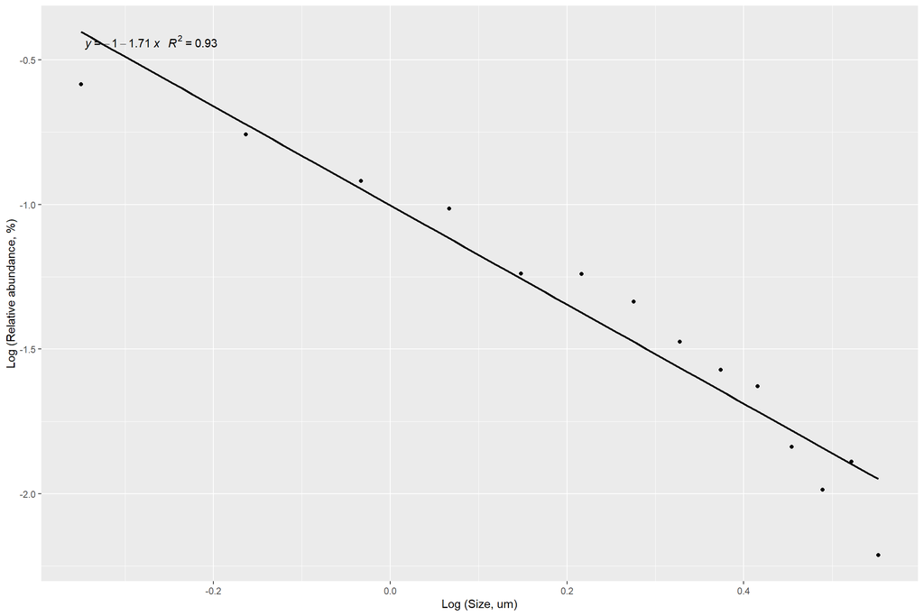

```r
ggplot(data = trimmedeffluent, aes(x = logSize, y = logAbundance)) +
   geom_smooth(method = "lm", se=FALSE, color="black", formula = my.formula) +
   stat_poly_eq(formula = my.formula,
                aes(label = paste(..eq.label.., ..rr.label.., sep = "~~~")),
                parse = TRUE) +
   geom_point() +
  xlab("Log (Size, um)") +
  ylab("Log (Relative abundance, %)")
```

### runoff

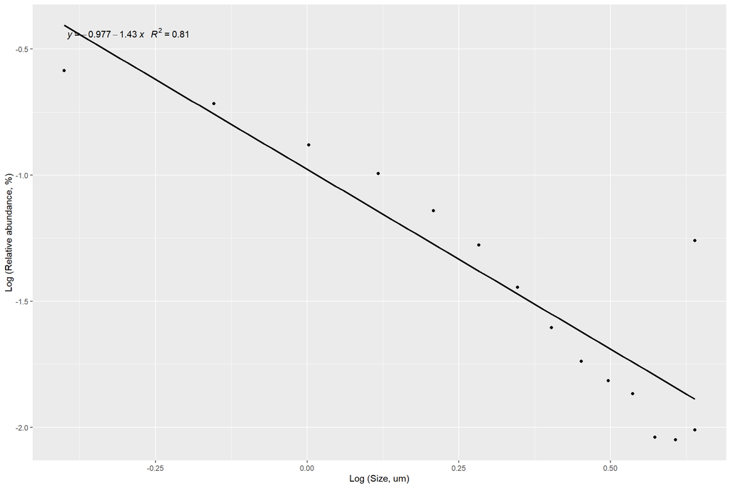

```r
#determine lower and upper end based on maximum R^2 (iteration required)
runoff_cut <- distributions %>%
  #filter(lower_size_limit_um == 125) %>%
 # filter(MorphologicalCategory == "Fragment") %>%
  filter(matrix == "runoff") %>%
  #filter(Size_um >1 & Size_um  <1000) %>%
  drop_na(Size_um)

#cut into bins
#runoffwinsors <- rbin_winsorize(runoff_cut, polymer, Size_um, 20)
runoffwinsors <- rbin_winsorize(runoff_cut, predictor = Length.mm, Length.mm, 15, winsor_rate = 0.05)
#save as dataframe
runoffbinned <- as.data.frame(runoffwinsors$bins) %>%
  dplyr::select(c(cut_point, bin_count, bin_prop))

#strip of characters
runoffbinned$cut <- gsub("[^0-9.-]","",runoffbinned$cut_point)
 #convert to numeric
runoffbinned2 <- runoffbinned %>%
  mutate(cut.numeric = as.numeric(cut)) %>%
  mutate(logAbundance = log10(bin_prop),
         logSize = log10(cut.numeric))

## model
library(ggpmisc)
my.formula <- y ~ x
p <- runoffbinned2 %>%
  #filter(logAbundance < -1.0) %>%
  ggplot(aes(x = logSize, y = logAbundance)) +
   geom_smooth(method = "lm", se=FALSE, color="black", formula = my.formula) +
   stat_poly_eq(formula = my.formula,
                aes(label = paste(..eq.label.., ..rr.label.., sep = "~~~")),
                parse = TRUE) +
   geom_point() +
  xlab("Log (Size, um)") +
  ylab("Log (Relative abundance, %)")
p
```

##### 1.2.3.0.2 Remove outliers

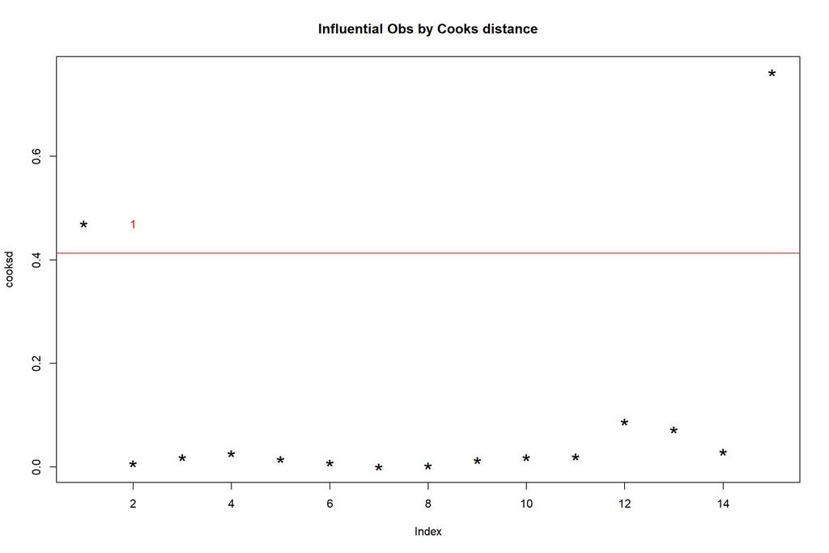

```r
runofflin <- lm(logAbundance ~ logSize, data = runoffbinned2)
cooksd <- cooks.distance(runofflin)
plot(cooksd, pch="*", cex=2, main="Influential Obs by Cooks distance")  # plot cook's distance
abline(h = 4*mean(cooksd, na.rm=T), col="red")  # add cutoff line
text(x=1:length(cooksd)+1, y=cooksd, labels=ifelse(cooksd>4*mean(cooksd, na.rm=T),names(cooksd),""), col="red")  # add labels
```

Extract outliers

```r
influential <- as.numeric(names(cooksd)[(cooksd > 4*mean(cooksd, na.rm=T))])  # influential row numbers
head(runoffbinned2[influential, ])  # influential observations.
```

```
##              cut_point bin_count   bin_prop               cut cut.numeric
## 1  < 0.397766666666667      1222 0.25939291 0.397766666666667   0.3977667
## 15 >= 4.35323333333333       259 0.05497771  4.35323333333333   4.3532333
##    logAbundance    logSize
## 1    -0.5860419 -0.4003716
## 15   -1.2598133  0.6388119
```

```r
trimmedrunoff <- runoffbinned2 %>%
  filter(cut_point != c(">= 4.35323333333333")
) %>%
  mutate(polymer = "runoff")

runofflin <- lm(logAbundance ~ logSize, data = trimmedrunoff)
runofflin.summ <- summary(runofflin)
runofflin.summ
```

```
##
## Call:
## lm(formula = logAbundance ~ logSize, data = trimmedrunoff)
##
## Residuals:
##       Min        1Q    Median        3Q       Max
## -0.256640 -0.049210 -0.004957  0.090653  0.164698
##
## Coefficients:
##             Estimate Std. Error t value Pr(>|t|)
## (Intercept) -0.97035    0.04809  -20.18 1.26e-10 ***
## logSize     -1.60087    0.11499  -13.92 9.10e-09 ***
## ---
## Signif. codes:  0 '***' 0.001 '**' 0.01 '*' 0.05 '.' 0.1 ' ' 1
##
## Residual standard error: 0.1281 on 12 degrees of freedom
## Multiple R-squared:  0.9417, Adjusted R-squared:  0.9368
## F-statistic: 193.8 on 1 and 12 DF,  p-value: 9.096e-09
```

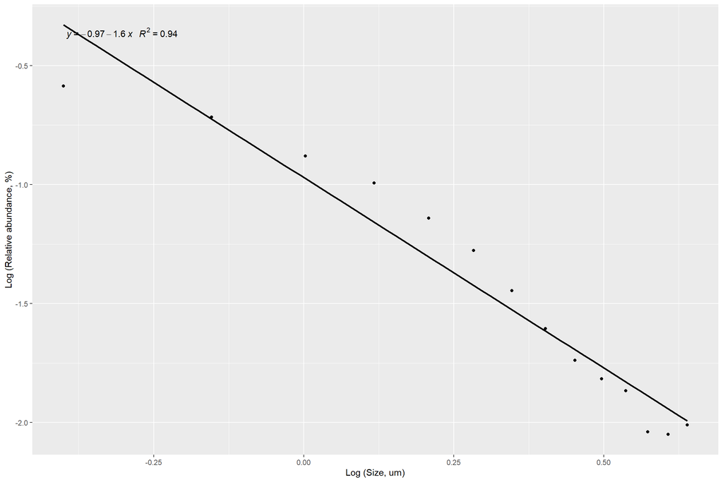

```r
ggplot(data = trimmedrunoff, aes(x = logSize, y = logAbundance)) +
   geom_smooth(method = "lm", se=FALSE, color="black", formula = my.formula) +
   stat_poly_eq(formula = my.formula,
                aes(label = paste(..eq.label.., ..rr.label.., sep = "~~~")),
                parse = TRUE) +
   geom_point() +
  xlab("Log (Size, um)") +
  ylab("Log (Relative abundance, %)")
```

### 1.2.4 Sediment

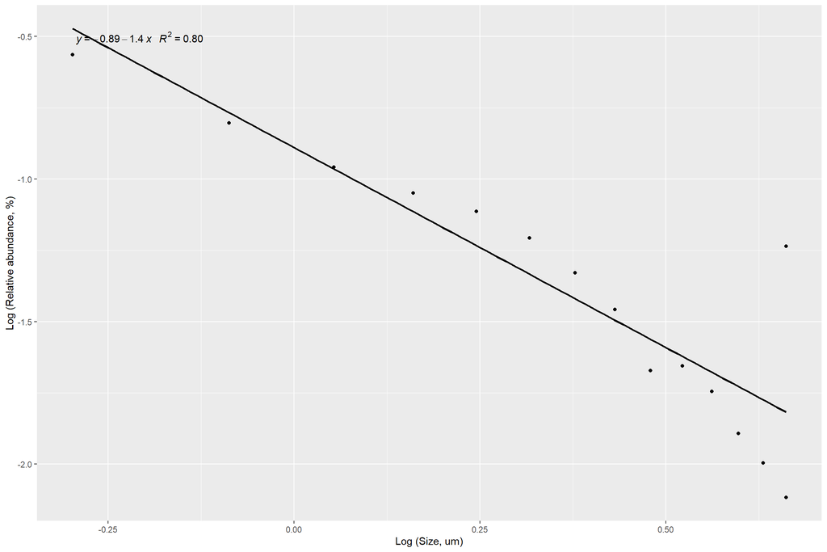

```r
#determine lower and upper end based on maximum R^2 (iteration required)
sediment_cut <- distributions %>%
  #filter(lower_size_limit_um == 125) %>%
 # filter(MorphologicalCategory == "Fragment") %>%
  filter(matrix == "sediment") %>%
  #filter(Size_um >1 & Size_um  <1000) %>%
  drop_na(Size_um)

#cut into bins
#sedimentwinsors <- rbin_winsorize(sediment_cut, polymer, Size_um, 20)
sedimentwinsors <- rbin_winsorize(sediment_cut, predictor = Length.mm, Length.mm, 15, winsor_rate = 0.05)
#save as dataframe
sedimentbinned <- as.data.frame(sedimentwinsors$bins) %>%
  dplyr::select(c(cut_point, bin_count, bin_prop))

#strip of characters
sedimentbinned$cut <- gsub("[^0-9.-]","",sedimentbinned$cut_point)
 #convert to numeric
sedimentbinned2 <- sedimentbinned %>%
  mutate(cut.numeric = as.numeric(cut)) %>%
  mutate(logAbundance = log10(bin_prop),
         logSize = log10(cut.numeric))

## model
library(ggpmisc)
my.formula <- y ~ x
p <- sedimentbinned2 %>%
  #filter(logAbundance < -1.0) %>%
  ggplot(aes(x = logSize, y = logAbundance)) +
   geom_smooth(method = "lm", se=FALSE, color="black", formula = my.formula) +
   stat_poly_eq(formula = my.formula,
                aes(label = paste(..eq.label.., ..rr.label.., sep = "~~~")),
                parse = TRUE) +
   geom_point() +
  xlab("Log (Size, um)") +
  ylab("Log (Relative abundance, %)")
p
```

##### 1.2.4.0.1 Remove outliers

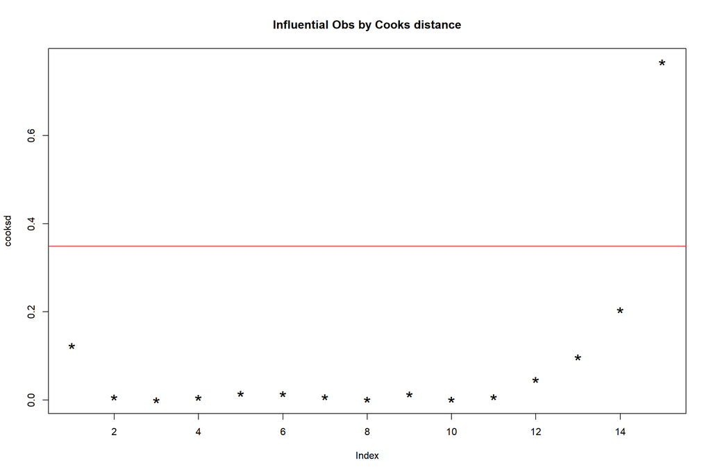

```r
sedimentlin <- lm(logAbundance ~ logSize, data = sedimentbinned2)
cooksd <- cooks.distance(sedimentlin)
plot(cooksd, pch="*", cex=2, main="Influential Obs by Cooks distance")  # plot cook's distance
abline(h = 4*mean(cooksd, na.rm=T), col="red")  # add cutoff line
text(x=1:length(cooksd)+1, y=cooksd, labels=ifelse(cooksd>4*mean(cooksd, na.rm=T),names(cooksd),""), col="red")  # add labels
```

Extract outliers

```r
influential <- as.numeric(names(cooksd)[(cooksd > 4*mean(cooksd, na.rm=T))])  # influential row numbers
head(sedimentbinned2[influential, ])  # influential observations.
```

```
##              cut_point bin_count   bin_prop              cut cut.numeric
## 15 >= 4.58422666666667       213 0.05808563 4.58422666666667    4.584227
##    logAbundance   logSize
## 15    -1.235931 0.6612661
```

```r
trimmedsediment <- sedimentbinned2 %>%
  filter(cut_point != c(">= 4.58422666666667")
) %>%
  mutate(polymer = "sediment")

sedimentlin <- lm(logAbundance ~ logSize, data = trimmedsediment)
sedimentlin.summ <- summary(sedimentlin)
sedimentlin.summ
```

```
##
## Call:
## lm(formula = logAbundance ~ logSize, data = trimmedsediment)
##
## Residuals:
##       Min        1Q    Median        3Q       Max
## -0.200276 -0.074667  0.006269  0.091488  0.166143
##
## Coefficients:
##             Estimate Std. Error t value Pr(>|t|)
## (Intercept) -0.87234    0.05118  -17.05 8.93e-10 ***
## logSize     -1.57960    0.11822  -13.36 1.45e-08 ***
## ---
## Signif. codes:  0 '***' 0.001 '**' 0.01 '*' 0.05 '.' 0.1 ' ' 1
##
## Residual standard error: 0.1227 on 12 degrees of freedom
## Multiple R-squared:  0.937,  Adjusted R-squared:  0.9318
## F-statistic: 178.5 on 1 and 12 DF,  p-value: 1.448e-08
```

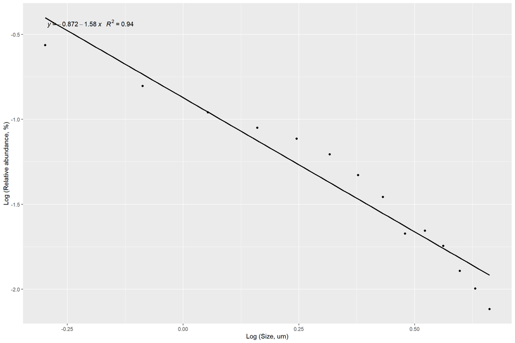

```r
ggplot(data = trimmedsediment, aes(x = logSize, y = logAbundance)) +
   geom_smooth(method = "lm", se=FALSE, color="black", formula = my.formula) +
   stat_poly_eq(formula = my.formula,
                aes(label = paste(..eq.label.., ..rr.label.., sep = "~~~")),
                parse = TRUE) +
   geom_point() +
  xlab("Log (Size, um)") +
  ylab("Log (Relative abundance, %)")
```

### 1.2.5 Compare individual and all combined

```r
names <- c("SamplWater", "Effluent", "Runoff", "Sediment")

preds <- c(sample_waterlin$coefficients[2], effluentlin$coefficients[2], runofflin$coefficients[2], sedimentlin$coefficients[2])

stderrors <- c(sample_waterlin.summ$coefficients[2,2], effluentlin.summ$coefficients[2,2], runofflin.summ$coefficients[2,2], sedimentlin.summ$coefficients[2,2])

R2 <- c(sample_waterlin.summ$r.squared, effluentlin.summ$r.squared, runofflin.summ$r.squared, sedimentlin.summ$r.squared)

p.values <- c(sample_waterlin.summ$coefficients[2,4], effluentlin.summ$coefficients[2,4], runofflin.summ$coefficients[2,4], sedimentlin.summ$coefficients[2,4])

summary <- tibble(names,preds, stderrors, R2, p.values)
write.csv(summary,"output/data/SFEI_summary_table.csv")
summary
```

```
## # A tibble: 4 x 5
##   names      preds stderrors    R2      p.values
##   <chr>      <dbl>     <dbl> <dbl>         <dbl>
## 1 SamplWater -1.78     0.111 0.956 0.00000000177
## 2 Effluent   -1.71     0.130 0.935 0.0000000176
## 3 Runoff     -1.60     0.115 0.942 0.00000000910
## 4 Sediment   -1.58     0.118 0.937 0.0000000145
```

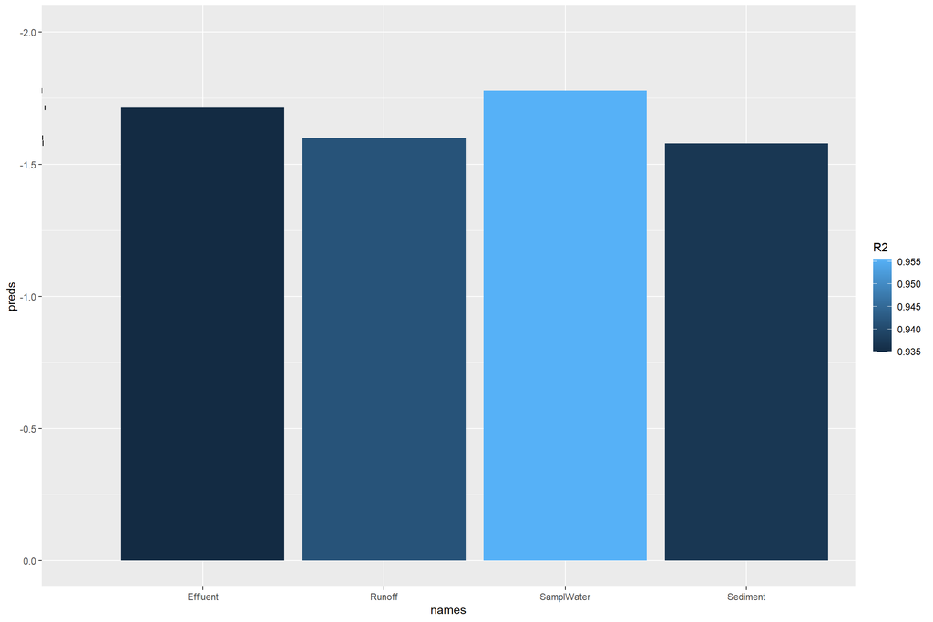

```r
summary %>%
  ggplot(aes(x = names, y = preds, fill = R2)) +
  geom_col() +
  geom_errorbar(aes(xmin = stderrors, xmax = stderrors)) +
  ylim(c(0, -2))
```

### 1.2.6 Fit distributions

The following section is incomplete.

Which distributions fits the data best?